# Data Science Capstone Final Project: Ranking National Cuisines and Fast Food Restaurants in Ten Cities

Boris Petelin

### Introduction

In this project we will try to answer the question, which would be of the most interest to travel agencies which include visiting the restaurants in their programmes. The question is as follows:

“Suppose that I'm a global traveler who loves visiting restaurants with national cuisines (ie American, Italian, Mexican, Chinese, etc.) in different cities. I'm interested in the rating of these cuisines based on user reviews for given ten cities; what are significant differences between the ratings and how they compare with the “fast food” restaurants. With which words the users most frequently express their satisfaction with excellent restaurants or disappointment with the bad ones?”

### Methods

1. Using the data from the academic datasets *business* and *review* from [Yelp Dataset Challenge](http://www.yelp.com/dataset_challenge)
2. Clustering cities from business dataset into 10 city clusters using the k-means clustering of geographical coordinates
3. Selecting restaurants with categories *American (New), American (Traditional), Burgers, Chinese, Fast Food, Italian, Japanese, Mexican, Pizza* and *Seafood* from *business* dataset
4. Adding *stars* from *review* dataset using *left join*
5. Exploratory analysis using the *boxplot* from *ggplot2*
6. Inferential statistics - pairwise comparison of the mean stars between categories within city clusters using *Welch Two Sample t-test*
7. Finding frequent words and associations in the *review* dataset texts (stars=5 and stars=1) using the *term document matrix*.

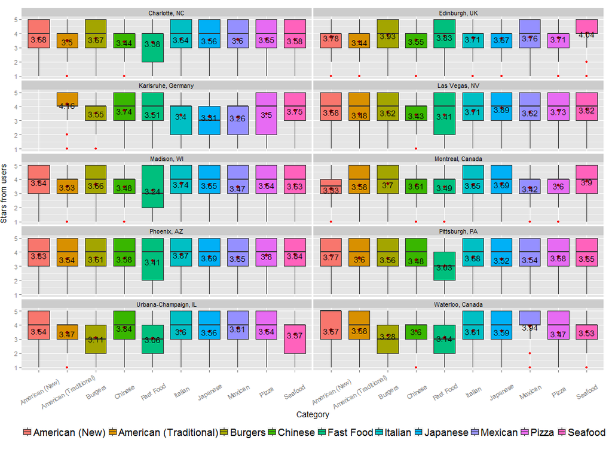

**Top**: Boxplot of the number of restaurant stars from user reviews, grouped by category and city cluster.  
**Right**: Table of ranking of restaurant categories grouped by city clusters. The categories that have no significant differences between the means of stars (pvalue > 0.05) are classified in the same rank. Conversely, there are significant differences in the average number of stars (_pvalue < 0.05_) between the categories in different ranks. The last column of the table shows the average number of stars within the corresponding rank.

Results: ranking restaurants

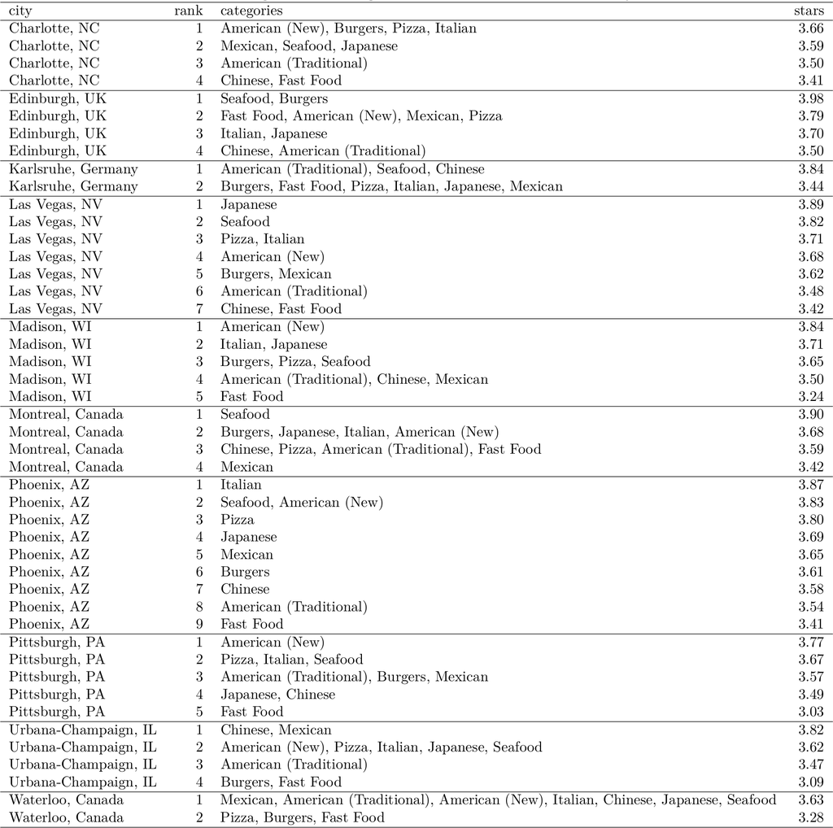

### Results: user reviews text mining

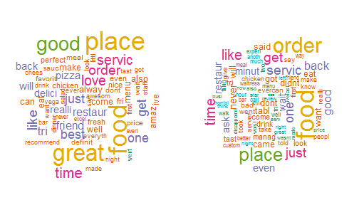

**Top**: Wordclouds of the most frequent terms used in user review texts: reviews with five stars (left), review with one star (right).  
**Bottom**: Correlations between four most frequent words and other words for five stars (left half of table) and one star reviews (right half of table).

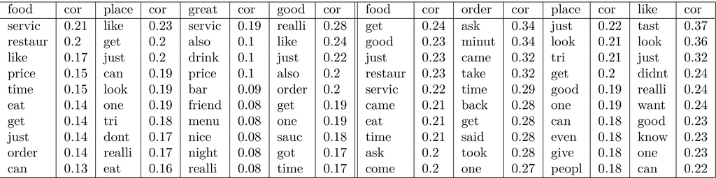